# Age-Standardised Testicular Cancer Incidence In The Nordic Countries

Data: **NORDCAN 2.0**, Association of the Nordic Cancer Registries / IARC, https://nordcan.iarc.fr, version 9.6 (06.2026), exported 20 September 2026. The exploratory report carries the full source description.

```r
source(if (file.exists("R/00_setup.R")) "R/00_setup.R" else "00_setup.R")
```

```r
library(readr)
library(dplyr)
library(tidyr)
library(ggplot2)
library(PHEindicatormethods)
library(broom)
```

# Load

```r
age_specific <- read_csv(proj_file("data/processed/testis_age_specific.csv"),
                         show_col_types = FALSE)

published <- read_csv(proj_file("data/processed/nordcan_published.csv"),
                      show_col_types = FALSE)

# stored as text, so the default sort would run 0-4, 10-14, 15-19, ..., 5-9, 85+
band_levels <- age_specific |>
  distinct(age_start, age_band) |>
  arrange(age_start) |>
  pull(age_band)

# the weight vector is positional, so row order inside each group is
# load-bearing. Checked as the file arrived, before any sorting of our own
rows_arrived_sorted <- all(tapply(age_specific$age_start,
                                  paste(age_specific$country, age_specific$period),
                                  \(x) !is.unsorted(x)))

age_specific <- age_specific |>
  mutate(age_band = factor(age_band, levels = band_levels, ordered = TRUE)) |>
  arrange(country, period, age_start)

band_order <- age_specific |>
  distinct(age_band, age_start) |>
  arrange(age_band)

stopifnot(
  "age_band levels are not the 18 expected five-year bands" =
    identical(levels(age_specific$age_band), EXPECTED_BANDS),
  "age_band level order does not ascend by age" =
    all(diff(band_order$age_start) > 0),
  "age_band is not an ordered factor" =
    is.ordered(age_specific$age_band),
  "age_specific is not countries x periods x age bands" =
    nrow(age_specific) == N_COUNTRIES * N_PERIODS * N_BANDS,
  "published is not countries x periods" =
    nrow(published) == N_COUNTRIES * N_PERIODS,
  "a country-period is missing some of its 18 age bands" =
    all(table(age_specific$country, age_specific$period) == N_BANDS),
  "the same age band appears twice in a country-period" =
    anyDuplicated(age_specific[c("country", "period", "age_start")]) == 0,
  "missing values in the prepared data" =
    !anyNA(age_specific) && !anyNA(published),
  "the input arrived with age bands out of order inside a country-period" =
    rows_arrived_sorted,
  "period_mid is not the midpoint of its own period" =
    all(age_specific$period_mid ==
          as.integer(substr(age_specific$period, 1, 4)) + 2)
)
```

These are the same two files the exploratory analysis used, and I run the same checks over them again. I would rather not assume the earlier stage left everything tidy.

# The Standard Population

Countries cannot be compared on raw rates, because their age profiles differ and the exploratory stage showed those profiles are shifting over time as well. The way round it is to reweight every country onto one shared reference population, so each is measured as if its age structure were the same as everyone else’s. That reference is the **European Standard Population 2013**, which is also what NORDCAN uses for its own published figures, so our numbers and theirs stay directly comparable.

One thing has to be squared away first. The published ESP2013 splits the population into 19 age groups and runs up to “90 and over”, while this data stops at “85 and over”. The two have to line up before any reweighting can happen, so the top two ESP2013 groups are added together into a single “85 and over” group, which leaves 18 to match the data. The weights are read straight from the package rather than typed in by hand, so a mistyped number cannot quietly change every result downstream.

```r
data(esp2013, package = "PHEindicatormethods")

esp18 <- c(esp2013[1:17], esp2013[18] + esp2013[19])

stopifnot(
  "the published ESP2013 vector is not 19 bands" = length(esp2013) == 19,
  "the collapsed vector is not 18 bands" = length(esp18) == N_BANDS,
  "collapsing changed the total weight" = sum(esp18) == sum(esp2013),
  "the top band is not the sum of the last two published weights" =
    esp18[18] == esp2013[18] + esp2013[19],
  # the four checks above all survive two weights being swapped with each
  # other, and a swap can land inside the tolerance, so compare the bands
  # that should not have moved at all
  "the first seventeen weights are not the published ones, in order" =
    identical(unname(esp18[1:17]), unname(esp2013[1:17]))
)

tibble(Measure = c("Published Bands", "Collapsed Bands",
                   "Total Weight", "Top Band Weight"),
       Value   = c(length(esp2013), length(esp18), sum(esp18), esp18[[18]]))
```

| Measure | Value |
| --- | --- |
| Published Bands | 19 |
| Collapsed Bands | 18 |
| Total Weight | 100000 |
| Top Band Weight | 2500 |

The table confirms the fold did what it was meant to. Nineteen groups became eighteen, the top group now carries 2,500, which is the two old top weights added together, and the total is still 100,000.

# Calculating The Standardised Rates

Everything that follows rests on this one calculation, so I work it out three times and check the answers against each other rather than trusting any single one. Once by hand, straight from the formula. Then with `phe_dsr()`, a function from a maintained public health package. Then with `calculate_dsr()`, the newer function that replaces it. If all three land on the same number, the calculation is doing what it is supposed to.

The two package functions are separate pieces of code but come from the same package and use the same underlying method, so this is really one hand calculation checked against two implementations rather than three fully independent routes.

```r
# the formula itself: each band's rate, weighted by the standard population
asr_hand <- age_specific |>
  group_by(country, period, period_mid) |>
  summarise(asr_hand = sum(esp18 * cases / person_years) / sum(esp18) * 1e5,
            .groups = "drop")

# phe_dsr takes the weights as a vector
asr_phe95 <- age_specific |>
  group_by(country, period) |>
  phe_dsr(cases, person_years, stdpop = esp18, stdpoptype = "vector",
          confidence = 0.95) |>
  select(country, period, asr = value, lower95 = lowercl, upper95 = uppercl)

# two levels in one call are only allowed as 0.95 and 0.998, so 99% runs separately
asr_phe99 <- age_specific |>
  group_by(country, period) |>
  phe_dsr(cases, person_years, stdpop = esp18, stdpoptype = "vector",
          confidence = 0.99) |>
  select(country, period, lower99 = lowercl, upper99 = uppercl)

# calculate_dsr rejects a bare vector and wants the weights as a column
asr_calc <- age_specific |>
  group_by(country, period) |>
  mutate(stdpop = esp18) |>
  calculate_dsr(cases, person_years, stdpop = stdpop, confidence = 0.95) |>
  ungroup() |>
  select(country, period, asr_calc = value)

asr <- asr_hand |>
  left_join(asr_phe95, by = c("country", "period")) |>
  left_join(asr_phe99, by = c("country", "period")) |>
  left_join(asr_calc,  by = c("country", "period")) |>
  left_join(select(published, country, period, asr_nordcan = asr_eu2013),
            by = c("country", "period"))
```

```r
stopifnot(
  "the ASR table is not one row per country-period" =
    nrow(asr) == N_COUNTRIES * N_PERIODS,
  "a country-period lost or gained a row in the joins" =
    anyDuplicated(asr[c("country", "period")]) == 0
)
```

```r
asr |>
  summarise(`Hand Against phe_dsr`        = max(abs(asr_hand - asr)),
            `phe_dsr Against calculate_dsr` = max(abs(asr - asr_calc)),
            `Ours Against NORDCAN`        = max(abs(asr - asr_nordcan))) |>
  pivot_longer(everything(), names_to = "Comparison",
               values_to = "Largest Difference")
```

| Comparison | Largest Difference |
| --- | --- |
| Hand Against phe_dsr | 0.0000000 |
| phe_dsr Against calculate_dsr | 0.0000000 |
| Ours Against NORDCAN | 0.0001498 |

All three land on the same number. Against NORDCAN’s own published figure the largest gap anywhere in the 35 country-periods is about 0.00015, which is small enough to be the rounding they apply when publishing rather than any real difference in how the rate was worked out.

# Validation Against NORDCAN

The section above showed the three calculations agree with each other. This one is the formal check against an outside answer. I set two tolerances before running any of this, and I test them here as code rather than reporting them as prose, so the report refuses to build if either one is missed.

```r
stopifnot(
  "hand-computed ASR and phe_dsr disagree by more than rounding" =
    max(abs(asr$asr_hand - asr$asr)) < 1e-9,
  "phe_dsr and calculate_dsr disagree" =
    max(abs(asr$asr - asr$asr_calc)) < 1e-9,
  "computed ASR is outside the pre-registered 0.05 tolerance against NORDCAN" =
    max(abs(asr$asr - asr$asr_nordcan)) < 0.05
)

asr |>
  filter(period == "1990-1994") |>
  transmute(Country = country,
            `Hand Computed` = round(asr_hand, 5),
            `phe_dsr` = round(asr, 5),
            `calculate_dsr` = round(asr_calc, 5),
            `NORDCAN Published` = round(asr_nordcan, 5))
```

| Country | Hand Computed | phe_dsr | calculate_dsr | NORDCAN Published |
| --- | --- | --- | --- | --- |
| Denmark | 10.04845 | 10.04845 | 10.04845 | 10.04845 |
| Finland | 2.62811 | 2.62811 | 2.62811 | 2.62811 |
| Iceland | 6.86203 | 6.86203 | 6.86203 | 6.86211 |
| Norway | 8.30772 | 8.30772 | 8.30772 | 8.30772 |
| Sweden | 4.84615 | 4.84615 | 4.84615 | 4.84614 |

The table takes one period and puts all four figures side by side, so the agreement can be seen rather than just asserted. Denmark’s 1990 to 1994 rate comes out at 10.04845 by hand, 10.04845 from each package function, and 10.04845 in NORDCAN’s published table.

# The Standardised Trend

With age differences removed, the countries can finally be put on one chart and read against each other.

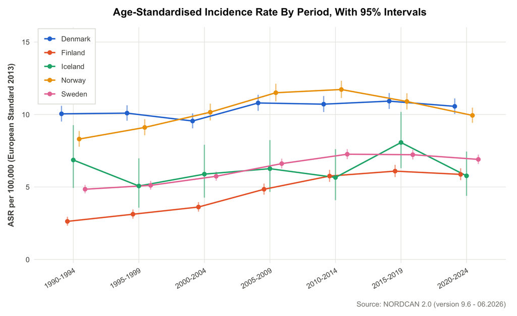

```r
# the five countries share an x position, so everything is nudged apart by the
# same amount to keep each country's interval readable
dodge <- position_dodge(width = 0.45)

ggplot(asr, aes(period, asr, group = country, colour = country)) +
  geom_errorbar(aes(ymin = lower95, ymax = upper95), width = 0,
                linewidth = 0.7, alpha = 0.55, position = dodge) +
  geom_line(linewidth = 0.8, position = dodge) +
  geom_point(size = 2, position = dodge) +
  scale_colour_manual(values = COUNTRY_COLORS) +
  # headroom at the top so the legend sits clear of every line
  scale_y_continuous(limits = c(0, NA),
                     expand = expansion(mult = c(0.02, 0.30))) +
  labs(title = "Age-Standardised Incidence Rate By Period, With 95% Intervals",
       x = NULL, y = "ASR per 100,000 (European Standard 2013)",
       caption = SOURCE_NOTE) +
  theme_eda() +
  legend_corner(0.01, 0.99) +
  theme(axis.text.x = element_text(angle = 30, hjust = 1))
```

What stands out is where the movement is, not that there is movement. Denmark barely shifts across the whole window, up about 5%, while Finland more than doubles. The countries converge because the bottom rises, not because the top comes down, which is a different story from the one a shrinking gap might suggest on its own. Iceland is the only country to finish lower than it started, and across the window its interval overlaps three of the other four at one point or another, more than any other country manages, so its place in the ranking is the least settled of the five.

```r
first_last <- range(asr$period)

asr |>
  filter(period %in% first_last) |>
  select(country, period, asr) |>
  pivot_wider(names_from = period, values_from = asr) |>
  mutate(Change = .data[[first_last[2]]] - .data[[first_last[1]]],
         `Percent Change` = (.data[[first_last[2]]] /
                               .data[[first_last[1]]] - 1) * 100) |>
  arrange(desc(`Percent Change`)) |>
  rename(Country = country) |>
  mutate(across(where(is.numeric), \(x) round(x, 1)))
```

| Country | 1990-1994 | 2020-2024 | Change | Percent Change |
| --- | --- | --- | --- | --- |
| Finland | 2.6 | 5.9 | 3.2 | 123.4 |
| Sweden | 4.8 | 6.9 | 2.1 | 42.5 |
| Norway | 8.3 | 9.9 | 1.6 | 19.6 |
| Denmark | 10.0 | 10.6 | 0.5 | 5.1 |
| Iceland | 6.9 | 5.8 | -1.1 | -15.9 |

```r
asr |>
  transmute(Country = country, Period = period, ASR = round(asr, 2),
            `95% Lower` = round(lower95, 2), `95% Upper` = round(upper95, 2),
            `99% Lower` = round(lower99, 2), `99% Upper` = round(upper99, 2)) |>
  arrange(Country, Period)
```

| Country | Period | ASR | 95% Lower | 95% Upper | 99% Lower | 99% Upper |
| --- | --- | --- | --- | --- | --- | --- |
| Denmark | 1990-1994 | 10.05 | 9.52 | 10.60 | 9.35 | 10.78 |
| Denmark | 1995-1999 | 10.10 | 9.57 | 10.64 | 9.42 | 10.81 |
| Denmark | 2000-2004 | 9.55 | 9.05 | 10.08 | 8.89 | 10.25 |
| Denmark | 2005-2009 | 10.80 | 10.25 | 11.36 | 10.09 | 11.54 |
| Denmark | 2010-2014 | 10.71 | 10.17 | 11.28 | 10.01 | 11.46 |
| Denmark | 2015-2019 | 10.92 | 10.38 | 11.48 | 10.22 | 11.66 |
| Denmark | 2020-2024 | 10.56 | 10.04 | 11.11 | 9.88 | 11.29 |
| Finland | 1990-1994 | 2.63 | 2.34 | 2.94 | 2.25 | 3.05 |
| Finland | 1995-1999 | 3.12 | 2.82 | 3.45 | 2.73 | 3.55 |
| Finland | 2000-2004 | 3.62 | 3.30 | 3.96 | 3.21 | 4.07 |
| Finland | 2005-2009 | 4.84 | 4.47 | 5.24 | 4.36 | 5.36 |
| Finland | 2010-2014 | 5.75 | 5.35 | 6.18 | 5.23 | 6.32 |
| Finland | 2015-2019 | 6.09 | 5.68 | 6.53 | 5.56 | 6.67 |
| Finland | 2020-2024 | 5.87 | 5.47 | 6.29 | 5.35 | 6.43 |
| Iceland | 1990-1994 | 6.86 | 4.93 | 9.27 | 4.42 | 10.08 |
| Iceland | 1995-1999 | 5.07 | 3.57 | 6.98 | 3.18 | 7.62 |
| Iceland | 2000-2004 | 5.89 | 4.27 | 7.91 | 3.84 | 8.60 |
| Iceland | 2005-2009 | 6.26 | 4.66 | 8.24 | 4.22 | 8.90 |
| Iceland | 2010-2014 | 5.66 | 4.09 | 7.62 | 3.67 | 8.28 |
| Iceland | 2015-2019 | 8.07 | 6.30 | 10.18 | 5.81 | 10.88 |
| Iceland | 2020-2024 | 5.77 | 4.39 | 7.44 | 4.01 | 8.00 |
| Norway | 1990-1994 | 8.31 | 7.78 | 8.86 | 7.62 | 9.04 |
| Norway | 1995-1999 | 9.11 | 8.57 | 9.68 | 8.40 | 9.86 |
| Norway | 2000-2004 | 10.16 | 9.59 | 10.75 | 9.42 | 10.94 |
| Norway | 2005-2009 | 11.50 | 10.91 | 12.12 | 10.72 | 12.32 |
| Norway | 2010-2014 | 11.73 | 11.14 | 12.33 | 10.96 | 12.52 |
| Norway | 2015-2019 | 10.90 | 10.35 | 11.47 | 10.18 | 11.65 |
| Norway | 2020-2024 | 9.94 | 9.42 | 10.47 | 9.27 | 10.65 |
| Sweden | 1990-1994 | 4.85 | 4.56 | 5.14 | 4.48 | 5.24 |
| Sweden | 1995-1999 | 5.11 | 4.82 | 5.42 | 4.73 | 5.51 |
| Sweden | 2000-2004 | 5.74 | 5.43 | 6.06 | 5.34 | 6.16 |
| Sweden | 2005-2009 | 6.61 | 6.28 | 6.95 | 6.18 | 7.06 |
| Sweden | 2010-2014 | 7.26 | 6.92 | 7.61 | 6.82 | 7.72 |
| Sweden | 2015-2019 | 7.23 | 6.90 | 7.57 | 6.80 | 7.68 |
| Sweden | 2020-2024 | 6.90 | 6.59 | 7.23 | 6.49 | 7.34 |

The 99% columns are a stricter version of the same interval, there as a check rather than as the headline figure. The reasoning is in the rate ratio section below.

The interval columns are the ones worth reading here, more than the rates themselves. In the final period Sweden’s 95% interval spans 0.64 and Iceland’s spans 3.05, nearly five times wider, for two countries whose point estimates sit about one apart. Widening from 95% to 99% barely moves the large countries and stretches Iceland noticeably further, which is the small-numbers problem turning up again in a second place.

# Rate Ratio By Period

This section reduces five separate rates down to the one number the research question actually asks for: how big is the gap.

The measure is straightforward. In each period, take the country with the highest rate and divide it by the country with the lowest. A value of 1 would mean no gap at all, and the further above 1 it sits the wider the spread. The pair is not decided in advance, because the extremes really do move. Denmark and Norway take turns at the top, Finland and Iceland take turns at the bottom, and four different pairings show up across the seven periods.

Each ratio carries its own margin of error, worked out by combining the uncertainty of whichever two countries are involved that period. One note for anyone checking the arithmetic: the intervals coming out of the standardisation step are slightly lopsided, and I treat them as even. On this data the two halves of an interval differ by about 1.5% in a typical case once you look at them on the log scale, so the approximation changes very little.

```r
Z95 <- qnorm(0.975)
Z99 <- qnorm(0.995)

# a log-scale variance recovered from each country's own interval
asr <- asr |>
  mutate(var_log = ((log(upper95) - log(lower95)) / (2 * Z95))^2)

rate_ratio <- asr |>
  group_by(period, period_mid) |>
  summarise(highest_country = country[which.max(asr)],
            lowest_country  = country[which.min(asr)],
            highest_asr     = max(asr),
            lowest_asr      = min(asr),
            var_log_ratio   = var_log[which.max(asr)] + var_log[which.min(asr)],
            # do the two extremes' own intervals overlap this period
            cis_overlap     = lower95[which.max(asr)] <= upper95[which.min(asr)],
            .groups = "drop") |>
  mutate(rate_ratio = highest_asr / lowest_asr,
         se_log     = sqrt(var_log_ratio),
         lower95    = exp(log(rate_ratio) - Z95 * se_log),
         upper95    = exp(log(rate_ratio) + Z95 * se_log),
         lower99    = exp(log(rate_ratio) - Z99 * se_log),
         upper99    = exp(log(rate_ratio) + Z99 * se_log))
```

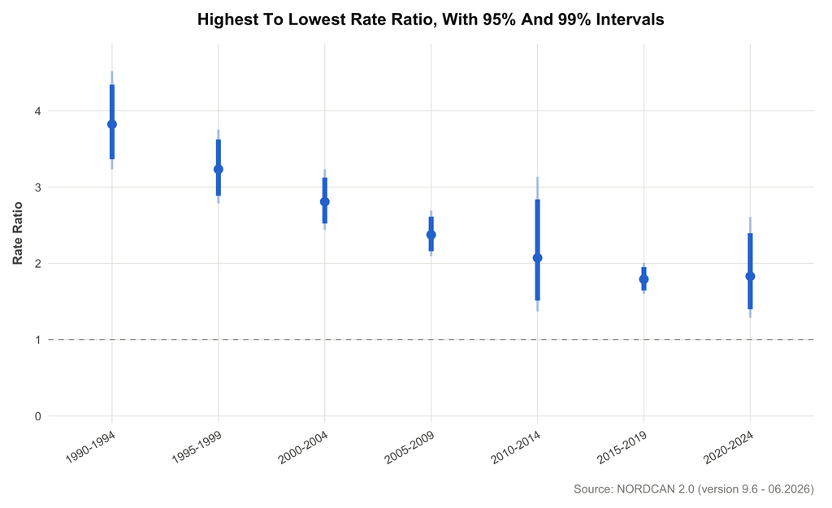

```r
ggplot(rate_ratio, aes(period, rate_ratio)) +
  # the 99% bar is the same hue faded, so it reads as the wider version of the
  # same interval rather than as a second measurement
  geom_errorbar(aes(ymin = lower99, ymax = upper99), width = 0,
                linewidth = 0.9, colour = COUNTRY_COLORS[["Denmark"]],
                alpha = 0.35) +
  geom_errorbar(aes(ymin = lower95, ymax = upper95), width = 0,
                linewidth = 1.8, colour = COUNTRY_COLORS[["Denmark"]]) +
  geom_point(size = 2.8, colour = COUNTRY_COLORS[["Denmark"]]) +
  geom_hline(yintercept = 1, linewidth = 0.3, linetype = "dashed",
             colour = INK_MUTED) +
  scale_y_continuous(limits = c(0, NA),
                     expand = expansion(mult = c(0.02, 0.08))) +
  labs(title = "Highest To Lowest Rate Ratio, With 95% And 99% Intervals",
       x = NULL, y = "Rate Ratio",
       caption = SOURCE_NOTE) +
  theme_eda() +
  theme(axis.text.x = element_text(angle = 30, hjust = 1))
```

The decline is gradual rather than sudden, and that matters for how it should be read: a gap that narrows in almost every period is a different thing from one that collapses once and then holds. The run of falls breaks only at the end, where the final period edges back up from 1.79 to 1.83. The two widest intervals on the chart, 2010 to 2014 and 2020 to 2024, are exactly the periods where Iceland is one of the extremes, so that closing uptick is also among the least precisely measured points on the chart.

The 99% bar is a stricter check rather than a correction. Read across seven periods, the chance that at least one 95% interval misses the true value is about 30%, and 99% is close to what a formal adjustment for seven comparisons would give. Neither interval allows for choosing the highest and lowest country each period.

```r
rate_ratio |>
  transmute(Period = period,
            Highest = highest_country, Lowest = lowest_country,
            `Rate Ratio` = round(rate_ratio, 2),
            `95% Interval` = sprintf("%.2f to %.2f", lower95, upper95),
            `99% Interval` = sprintf("%.2f to %.2f", lower99, upper99),
            `Extremes Overlap` = ifelse(cis_overlap, "Yes", "No"))
```

| Period | Highest | Lowest | Rate Ratio | 95% Interval | 99% Interval | Extremes Overlap |
| --- | --- | --- | --- | --- | --- | --- |
| 1990-1994 | Denmark | Finland | 3.82 | 3.37 to 4.34 | 3.23 to 4.52 | No |
| 1995-1999 | Denmark | Finland | 3.23 | 2.89 to 3.62 | 2.79 to 3.76 | No |
| 2000-2004 | Norway | Finland | 2.81 | 2.52 to 3.13 | 2.44 to 3.23 | No |
| 2005-2009 | Norway | Finland | 2.38 | 2.16 to 2.61 | 2.10 to 2.69 | No |
| 2010-2014 | Norway | Iceland | 2.07 | 1.51 to 2.84 | 1.37 to 3.14 | No |
| 2015-2019 | Denmark | Finland | 1.79 | 1.65 to 1.95 | 1.60 to 2.01 | No |
| 2020-2024 | Denmark | Iceland | 1.83 | 1.40 to 2.40 | 1.29 to 2.61 | No |

That points at something the Extremes Overlap column cannot tell you. It compares the top country’s lower bound against the bottom country’s upper bound, and those are far apart in every period, which is why it reads No throughout. It confirms that a gap exists; it says nothing about *which* country sits at each end. On that question the labels are shakier than they look. In 2015 to 2019 Denmark and Norway are 0.03 apart with almost identical intervals, so naming Denmark the highest is close to a coin flip, and the same goes for Finland against Iceland at the bottom in 2010 to 2014 and 2020 to 2024.

The reassuring part is that this barely touches the answer. Swapping every one of those near-tied labels moves the ratios by at most 0.035 and the trend slope from -0.0291 to -0.0293. The size of the gap is solid. The names attached to its two ends, in those particular periods, are not.

# Trend Test

Looking at the chart above, the gap obviously shrinks. I did not want to rest on reading a slope off a picture though, so I tested it properly. I fitted a straight line through the seven ratios against the midpoint year of each period, working on the log scale so the slope reads as a percentage change rather than a fixed amount, and I weighted each period by how certain it is, so the shakier readings pull the line around less than the solid ones.

```r
trend_fit <- lm(log(rate_ratio) ~ period_mid,
                data = rate_ratio, weights = 1 / var_log_ratio)

trend_tidy <- tidy(trend_fit, conf.int = TRUE)

trend_tidy |>
  filter(term == "period_mid") |>
  transmute(`Slope Per Year` = round(estimate, 5),
            `Standard Error` = round(std.error, 5),
            `95% Lower` = round(conf.low, 5),
            `95% Upper` = round(conf.high, 5),
            `P Value` = signif(p.value, 3),
            `Annual Change` = sprintf("%.2f%%", (exp(estimate) - 1) * 100),
            `Change Over 30 Years` = sprintf("%.1f%%", (exp(estimate * 30) - 1) * 100))
```

| Slope Per Year | Standard Error | 95% Lower | 95% Upper | P Value | Annual Change | Change Over 30 Years |
| --- | --- | --- | --- | --- | --- | --- |
| -0.02911 | 0.00145 | -0.03283 | -0.02539 | 5.6e-06 | -2.87% | -58.2% |

The slope comes out around twenty times its own standard error, which is why the p value lands where it does. A decline this consistent is not the sort of thing seven noisy points throw up by chance. A more intuitive way to read the annual figure is this: keep going at that rate and the gap halves roughly every 24 years.

One thing worth holding onto, though. This measures the trend in the *ratio*, not in anyone’s risk. A ratio can shrink while every country’s rate is climbing, and that is close to what is happening here.

```r
tq    <- qt(0.975, df.residual(trend_fit))
slope <- coef(trend_fit)[["period_mid"]]

se_relative <- sqrt(diag(vcov(trend_fit)))[["period_mid"]]
se_exact    <- sqrt(diag(vcov(trend_fit)) /
                      summary(trend_fit)$sigma^2)[["period_mid"]]

tibble(Weighting = c("Weights Treated As Relative",
                     "Weights Treated As Exact"),
       se = c(se_relative, se_exact)) |>
  transmute(Weighting,
            `Standard Error` = round(se, 5),
            `95% Lower` = round(slope - tq * se, 4),
            `95% Upper` = round(slope + tq * se, 4),
            `Fall Over 30 Years` =
              sprintf("%.0f%% to %.0f%%",
                      -(exp((slope + tq * se) * 30) - 1) * 100,
                      -(exp((slope - tq * se) * 30) - 1) * 100))
```

| Weighting | Standard Error | 95% Lower | 95% Upper | Fall Over 30 Years |
| --- | --- | --- | --- | --- |
| Weights Treated As Relative | 0.00145 | -0.0328 | -0.0254 | 53% to 63% |
| Weights Treated As Exact | 0.00254 | -0.0356 | -0.0226 | 49% to 66% |

The weights are treated as relative rather than exact, which is how the fitting function handles them by default, so the standard error reflects how closely the seven points sit around the line. They sit closer than their stated uncertainties implied. Taking those uncertainties at face value instead widens the 95% interval on the slope from -0.0328 to -0.0254 out to -0.0356 to -0.0226. That is a fall in the gap of roughly 49% to 66% over the 30 years, instead of 53% to 63%. The conclusion is the same either way.

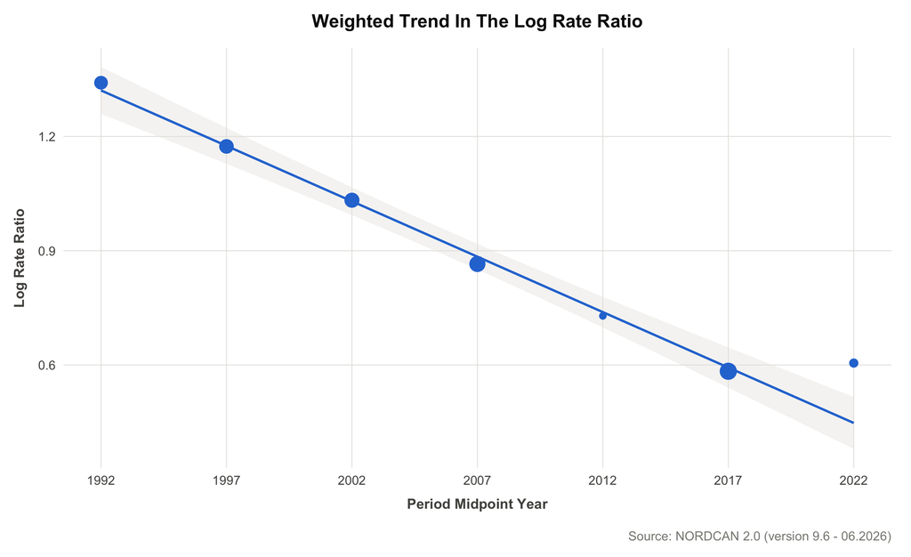

```r
ggplot(rate_ratio, aes(period_mid, log(rate_ratio))) +
  geom_smooth(aes(weight = 1 / var_log_ratio), method = "lm", formula = y ~ x,
              colour = COUNTRY_COLORS[["Denmark"]], fill = GRID, linewidth = 0.8) +
  geom_point(aes(size = 1 / var_log_ratio),
             colour = COUNTRY_COLORS[["Denmark"]], show.legend = FALSE) +
  scale_size_continuous(range = c(1.8, 5)) +
  scale_x_continuous(breaks = rate_ratio$period_mid) +
  labs(title = "Weighted Trend In The Log Rate Ratio",
       x = "Period Midpoint Year", y = "Log Rate Ratio",
       caption = SOURCE_NOTE) +
  theme_eda()
```

The slope is negative and clearly separated from zero, at roughly 2.9% off the ratio each year with a p value near 0.0000056. Carried across the 30 years between the first and last midpoints, that is a fall of about 58% in the size of the gap. Larger points on the chart are the periods with tighter intervals, which is the weighting made visible: the later Iceland-driven periods count for less in fitting the line.

The gap between the highest and lowest Nordic country has narrowed substantially across the study window, and the narrowing is larger than the uncertainty around it. Why it narrowed is a separate question that this project does not take up.